# **AIML Module Project - Applied Statistics** - Total Score 60

#### I. Select only the Event that has ‘disrupt’ keyword from 2013 onwards. [1 Mark]

```python
#Checking distribution of Event Variable
mydataEvent = mydata_raw.copy(deep = True)
mydataEvent['Event']
mydataEvent['Event'].value_counts()
```

```
TC50 2008                    52
TC50 2009                    50
TC40 2007                    40
Disrupt NYC 2011             32
Disrupt SF 2013              31
Disrupt SF 2011              31
Disrupt NYC 2013             31
Disrupt SF 2012              30
Disrupt NYC 2012             30
Disrupt SF 2014              28
Disrupt SF 2015              27
Disrupt NYC 2014             27
Disrupt SF 2010              26
Disrupt SF 2016              26
Disrupt NY 2015              26
Disrupt NY 2016              22
Disrupt NYC 2010             22
Disrupt Beijing 2011         18
Disrupt EU 2013              15
Hardware Battlefield 2015    15
Disrupt EU 2014              15
Disrupt London 2015          15
Hardware Battlefield 2014    14
Disrupt London 2016          13
-                            13
Hardware Battlefield 2016    13
Name: Event, dtype: int64
```

```python
mydataEvent['Event_Year'] = mydataEvent['Event'].str[-4:]
```

```python
mydataEvent_2013 = mydataEvent.loc[(mydataEvent['Event_Year']>='2013')]
```

```python
mydataEvent_2013_Disrupt = mydataEvent_2013[mydataEvent_2013['Event'].str.contains('Disrupt')]
```

```python
mydataEvent_2013_Disrupt['Event'].value_counts()
```

```
Disrupt SF 2013        31
Disrupt NYC 2013       31
Disrupt SF 2014        28
Disrupt SF 2015        27
Disrupt NYC 2014       27
Disrupt SF 2016        26
Disrupt NY 2015        26
Disrupt NY 2016        22
Disrupt EU 2013        15
Disrupt EU 2014        15
Disrupt London 2015    15
Disrupt London 2016    13
Name: Event, dtype: int64
```

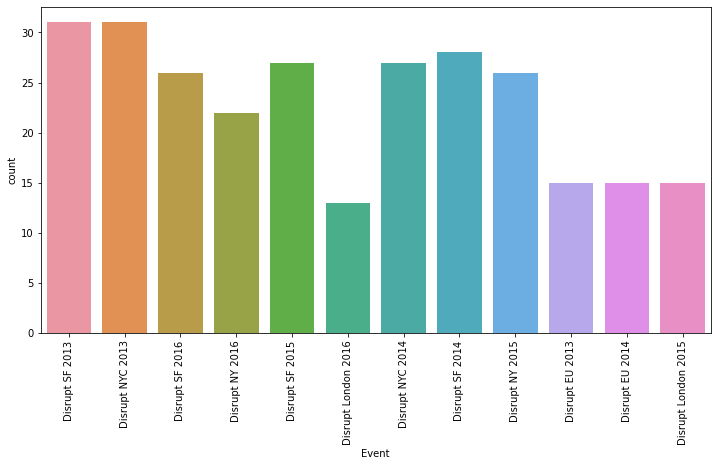

```python
#Plotting Event with 'disrupt' and from 2013
plt.figure(figsize=(12,6))
sns.countplot(mydataEvent_2013_Disrupt['Event'])
plt.xticks(rotation=90);
```

## Observation on the data points collected to perform better analysis

## Quality

• We had to discard 216 entries due to unavailable data, resulting in a reduced usable data set.

• Pre-processed data will hep save time for analysis ( such as capturing Event location, year and Funds in separate columns and in the right format.

• Hence, complete data sets would be beneficial to perform statistical analyses

• Specifically, data on the P&L status, employee strength, geographic presence, and a more frequently updated Funding and Operating State will be helpful.

## Quantity

• The overall usable data is very low. Hypothesis testing is effective with higher sample sizes. When we apply filtered cuts on the data, the sample size tends to go close to the 30 cut-off, there by affecting our normality assumptions. Hence, we should try to collect more data amongst each cut that we want to analyze that is representative of the population

• In fact, if we want to test our hypothesis on individual Winner Classes, it won’t be possible since a few have < 30 samples

## Variety

• Data from a variety of sources such as blog articles, press releases etc could be tracked to update our database

• Specifically, data on P&L statements social media activity/posts from the company, press releases and its contents could provide added information on the company’s health and funding.